# practical machine learning project

Alla Aleksandrova

15 september 2019 г

# Goal

The goal is to predict the manner in which people did the exercise.

# Summary

*Data Preparation*  
1. Download and load data sets,  
2. Preprocess data set: create partition and filter out the training and test data set,  
3. Find out the less useful predictors,  
4. Look into correlations.

*Model Building*  
5. Fit model on three methods:  
a) Random Forest,  
b) Decision Tree,  
c) Generalized Boosted Model;  
6. Print accuracy of the built models.

# Data preparation results

```r
library(caret); library(knitr);library(randomForest)
```

```r
library(rattle); library(rpart.plot);library(rpart)
library(gbm); library(corrplot); library(ggplot2)
library(colorspace); library(e1071)
#load("pml-testing.csv")
#load("pml-training.csv")
#load data
trainData <- read.csv("pml-training.csv"); dim(trainData)
```

```
## [1] 19622   160
```

```r
testData <- read.csv("pml-testing.csv"); dim(testData)
```

```
## [1]  20 160
```

```r
set.seed(100)
#create sets
inTrain<-createDataPartition(y=trainData$classe, p=0.7, list=FALSE)
trainSet<- trainData[inTrain, ]
cvSet<- trainData[-inTrain, ]
#find variables near zero
NZV <- nearZeroVar(trainSet)
trainSet <- trainSet[, -NZV]
cvSet  <- cvSet[, -NZV]
dim(trainSet)
```

```
## [1] 13737   105
```

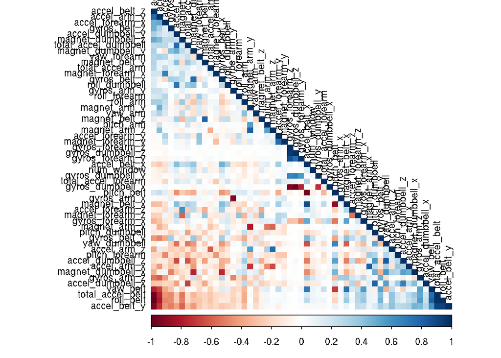

```r
#remove variables that are mostly NA (mNA)
mostlyNA <- sapply(trainSet, function(x) mean(is.na(x))) > 0.95
trainSet <- trainSet[, mostlyNA==FALSE]
cvSet <- cvSet[, mostlyNA==FALSE]
#remove identification only variables (columns 1 to 5)
trainSet <- trainSet[, -(1:5)]
cvSet <- cvSet[, -(1:5)]

corMatrix <- cor(trainSet[, -54])
corrplot(corMatrix, order = "FPC", method = "color", type = "lower",
         tl.cex = 0.8, tl.col = rgb(0, 0, 0))
```

# Model building results

```r
trControlRF <-trainControl(method = "cv", number = 3, verbose = FALSE)
modFitRF <-train(classe ~ ., data = trainSet, method = "rf", trControl = trControlRF)
modFitRF$finalModel
```

```
##
## Call:
##  randomForest(x = x, y = y, mtry = param$mtry)
##                Type of random forest: classification
##                      Number of trees: 500
## No. of variables tried at each split: 27
##
##         OOB estimate of  error rate: 0.2%
## Confusion matrix:
##      A    B    C    D    E  class.error
## A 3904    1    0    0    1 0.0005120328
## B    6 2649    2    1    0 0.0033860045
## C    0    3 2392    1    0 0.0016694491
## D    0    0    5 2246    1 0.0026642984
## E    0    1    0    6 2518 0.0027722772
```

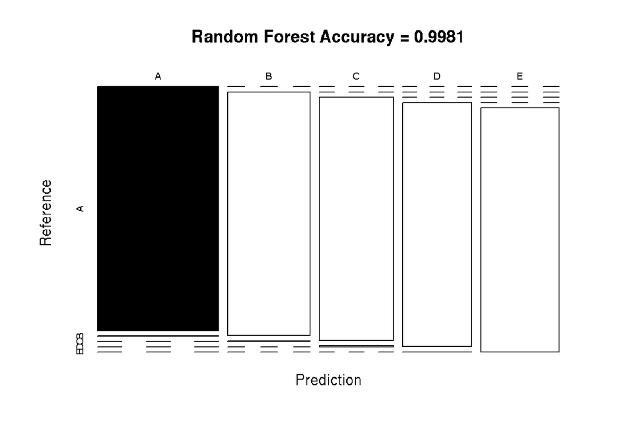

```r
predictRF <- predict(modFitRF, newdata = cvSet)
confMatrixRF <- confusionMatrix(predictRF, cvSet$classe)

plot(confMatrixRF$table, col = confMatrixRF$byClass,
     main = paste("Random Forest Accuracy =",
                  round(confMatrixRF$overall['Accuracy'], 4)))
```

Decision Tree Accuracy

[figure not shown]

```r
modFitDT <- rpart(classe ~ ., data=trainSet, method="class")
fancyRpartPlot(modFitDT)
```

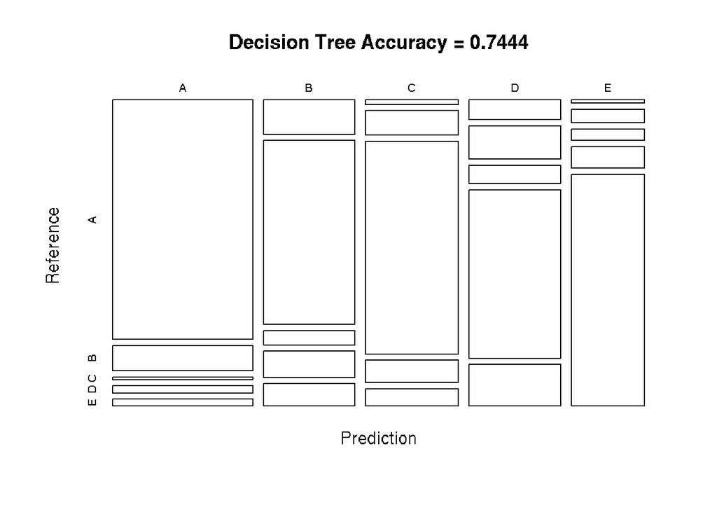

```r
predictDT <- predict(modFitDT, newdata=cvSet, type="class")
confMatrixDT <- confusionMatrix(predictDT, cvSet$classe)
plot(confMatrixDT$table, col = confMatrixDT$byClass,
     main = paste("Decision Tree Accuracy =",
                  round(confMatrixDT$overall['Accuracy'], 4)))
```

Generalized Boosted Model Accuracy

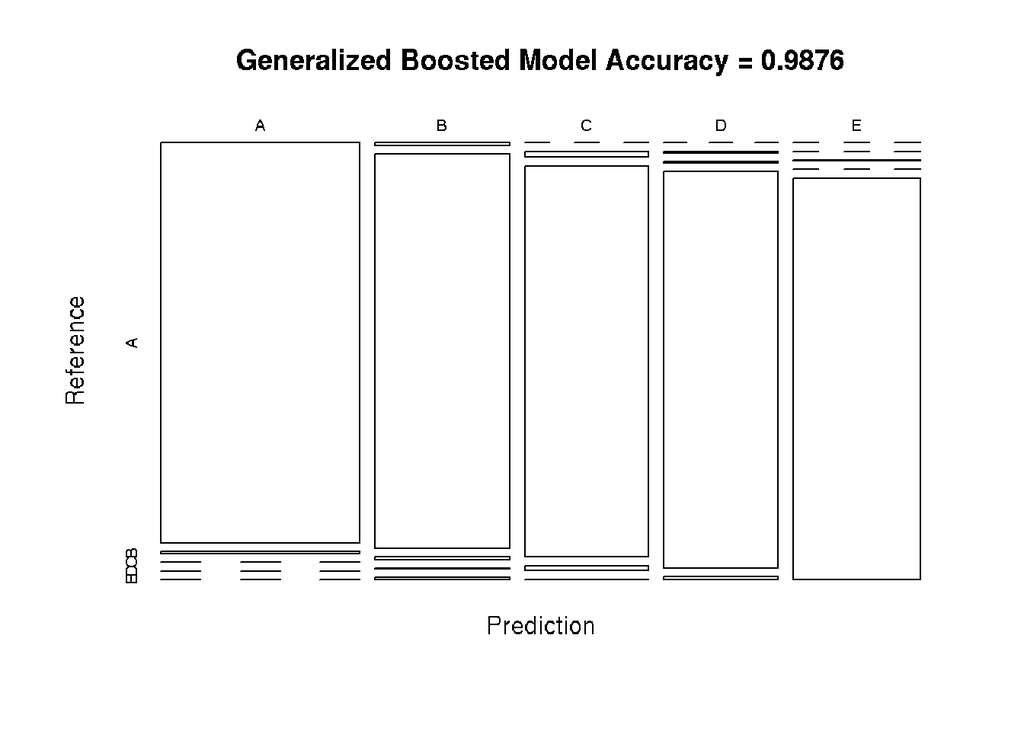

```r
trControlGBM <- trainControl(method = "repeatedcv", number = 5, repeats = 1)
modFitGBM  <- train(classe ~ ., data=trainSet, method = "gbm",
                    trControl = trControlGBM, verbose = FALSE)

predictGBM <- predict(modFitGBM, newdata=cvSet)
confMatrixGBM <- confusionMatrix(predictGBM, cvSet$classe)
plot(confMatrixGBM$table, col = confMatrixGBM$byClass,
     main = paste("Generalized Boosted Model Accuracy =",
                  round(confMatrixGBM$overall['Accuracy'], 4)))
```

After fitting our models the best accuracy is RandomForest Accuracy. The accuracy is 99.8%, thus my predicted accuracy for the out-of-sample error is 0.2%.

Then I tried to combine predictors to improve accuracy.

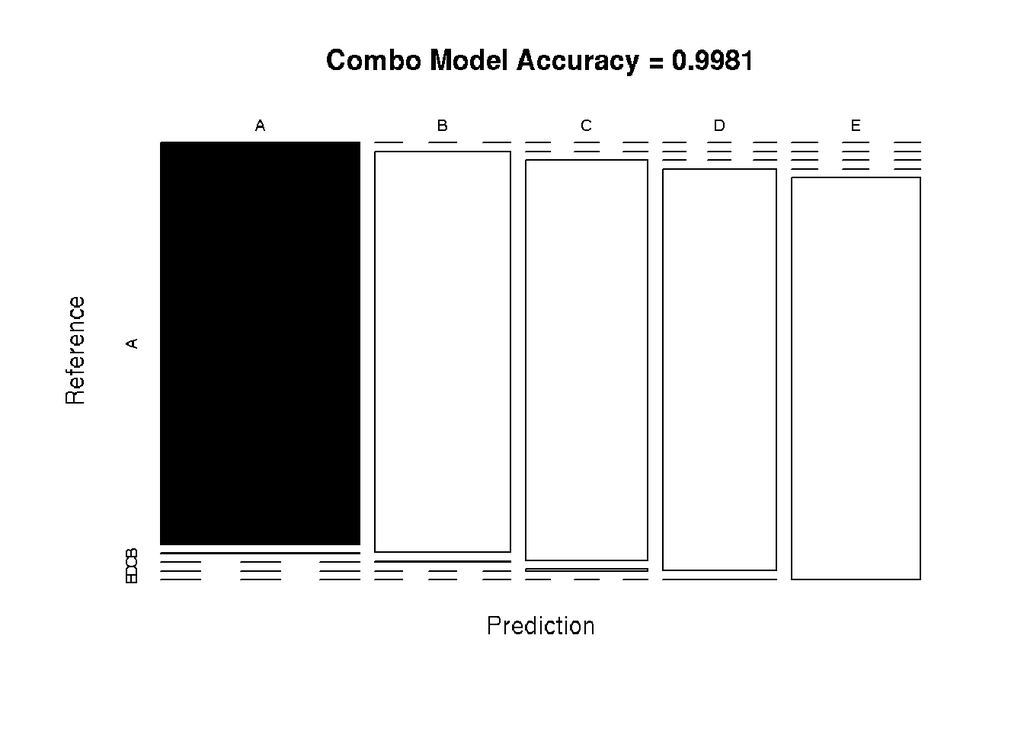

```r
combo<-data.frame(predictRF,predictGBM,predictDT, classe = cvSet$classe)

modCombo<-train(classe ~ ., data = combo, method = "rf")
prCombo<-predict(modCombo, cvSet)
confMatrixCmb <- confusionMatrix(prCombo, cvSet$classe)
plot(confMatrixCmb$table, col = confMatrixCmb$byClass,
     main = paste("Combo Model Accuracy =",
                  round(confMatrixCmb$overall['Accuracy'], 4)))
```

```r
#summary(predictTEST)
modFitRF <-train(classe ~ ., data = trainSet, method = "rf", trControl = trControlRF)
predictTEST <- predict(modFitRF, newdata=testData)
predictTEST <- c(as.character(predictTEST))
predictTEST
```

```
##  [1] "B" "A" "B" "A" "A" "E" "D" "B" "A" "A" "B" "C" "B" "A" "E" "E" "A"
## [18] "B" "B" "B"
```

```r
outOfSampleError.accuracy <- sum(predictTEST == cvSet$classe)/length(predictTEST)
outOfSampleError <- 1 - outOfSampleError.accuracy
outOfSampleError
```

```
## [1] -64.2
```